# Gitting the Crab data fixed

## Backstory

Tanner crabs were captured and brought back in the lab to be tested for the presence of bitter crab disease. Crabs were then placed in three different temperature treatments to examine how temperature influences disease progression.

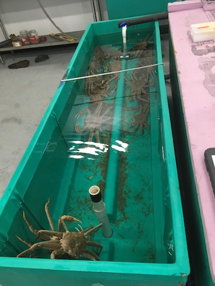

tank

## Data Wrangling Problem

There are a lot of crabs. We have intitial design data including presumed disease state (cPCR), quantitative PCR confirming disease status, and RNA levels. We need to decide on which crabs will be used to construct RNA-seq libraries to look at immune response genes.

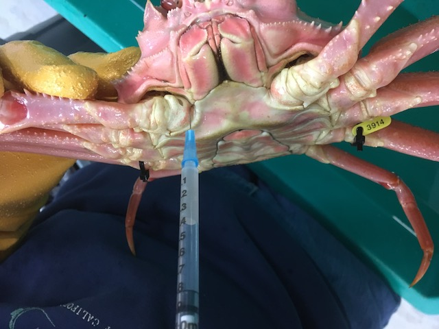

needle

## The Starting table

Here is what the "Master" looks like. What is wrong here?

[figure not shown]

ss

## Bringing in data

```r
library(tidyverse)
```

## Bringing in data

```r
    prim_master <- read_csv("../data/20180522-master-all-crabs-hemo-mod3.csv")
```

## Issue?

```r
knitr::kable(prim_master)
```

| FRP No. | FRP | infection_cpcr-d0 | maturity | CW | SC | CH | holdtank | TREATMENT | lowtag | hightag | treattank | where | tube_no |
| --- | --- | --- | --- | --- | --- | --- | --- | --- | --- | --- | --- | --- | --- |
| 2017-6101 | 6101 | 0 | I | 115.7 | 3 | 20.4 | 7A | A | 3001 | 3035 | 1 | drain end | 84 |
| 2017-6101 | 6101 | 0 | I | 115.7 | 3 | 20.4 | 1C | C | 3001 | 3035 | 1 | drain end | 206 |
| 2017-6101 | 6101 | 0 | I | 115.7 | 3 | 20.4 | 1C | C | 3001 | 3035 | 1 | drain end | 415 |
| 2017-6102 | 6102 | 0 | I | 110.4 | 4 | 15.4 | 8A | A | 3004 | 3219 | 2 | drain end | 18 |
| 2017-6102 | 6102 | 0 | I | 110.4 | 4 | 15.4 | 2C | C | 3004 | 3219 | 2 | drain end | 236 |
| 2017-6102 | 6102 | 0 | I | 110.4 | 4 | 15.4 | 2C | C | 3004 | 3219 | 2 | drain end | 439 |
| 2017-6103 | 6103 | 1 | I | 83.5 | 3 | 10.8 | 9A | A | 3007 | 3119 | 1 | drain end | 46 |
| 2017-6103 | 6103 | 1 | I | 83.5 | 3 | 10.8 | 1C | C | 3007 | 3119 | 1 | drain end | 215 |
| 2017-6103 | 6103 | 1 | I | 83.5 | 3 | 10.8 | 1C | C | 3007 | 3119 | 1 | drain end | 409 |
| 2017-6104 | 6104 | 0 | I | 81.6 | 3 | 11.0 | 9A | A | 3008 | 3472 | 3 | drain end | 41 |
| 2017-6104 | 6104 | 0 | I | 81.6 | 3 | 11.0 | 3C | C | 3008 | 3472 | 3 | drain end | 259 |
| 2017-6104 | 6104 | 0 | I | 81.6 | 3 | 11.0 | 3C | C | 3008 | 3472 | 3 | drain end | 458 |
| 2017-6105 | 6105 | 1 | I | 119.8 | 3 | 19.2 | 9A | A | 3019 | 3504 | 2 | drain end | 43 |
| 2017-6105 | 6105 | 1 | I | 119.8 | 3 | 19.2 | 2C | C | 3019 | 3504 | 2 | drain end | 234 |
| 2017-6105 | 6105 | 1 | I | 119.8 | 3 | 19.2 | 2C | C | 3019 | 3504 | 2 | drain end | 438 |
| 2017-6106 | 6106 | 0 | M | 113.8 | 3 | 20.5 | 8A | A | 3020 | 3509 | 3 | drain end | 5 |
| 2017-6106 | 6106 | 0 | M | 113.8 | 3 | 20.5 | 3C | C | 3020 | 3509 | 3 | drain end | 241 |
| 2017-6106 | 6106 | 0 | M | 113.8 | 3 | 20.5 | 3C | C | 3020 | 3509 | 3 | drain end | 450 |
| 2017-6107 | 6107 | 0 | M | 132.9 | 4 | 29.7 | 3C | C | 3024 | 3597 | 7 | drain end | 115 |
| 2017-6107 | 6107 | 0 | M | 132.9 | 4 | 29.7 | 7A | A | 3024 | 3597 | 7 | drain end | 350 |
| 2017-6107 | 6107 | 0 | M | 132.9 | 4 | 29.7 | 7A | A | 3024 | 3597 | 7 | drain end | 471 |
| 2017-6108 | 6108 | 1 | I | 131.9 | 3 | 19.6 | 8A | A | 3032 | 3442 | 3 | drain end | 6 |
| 2017-6108 | 6108 | 1 | I | 131.9 | 3 | 19.6 | 3C | C | 3032 | 3442 | 3 | drain end | 255 |
| 2017-6108 | 6108 | 1 | I | 131.9 | 3 | 19.6 | 3C | C | 3032 | 3442 | 3 | drain end | 455 |
| 2017-6109 | 6109 | 0 | I | 128.8 | 3 | 18.9 | 8A | A | 3034 | 3217 | 7 | drain end | 31 |
| 2017-6109 | 6109 | 0 | I | 128.8 | 3 | 18.9 | 7A | A | 3034 | 3217 | 7 | drain end | 351 |
| 2017-6109 | 6109 | 0 | I | 128.8 | 3 | 18.9 | 7A | A | 3034 | 3217 | 7 | drain end | 480 |
| 2017-6110 | 6110 | 0 | I | 123.4 | 0 | 19.2 | 2C | C | 3049 | 3337 | 8 | drain end | 135 |
| 2017-6110 | 6110 | 0 | I | 123.4 | 0 | 19.2 | 8A | A | 3049 | 3337 | 8 | drain end | 331 |
| 2017-6110 | 6110 | 0 | I | 123.4 | 0 | 19.2 | 8A | A | 3049 | 3337 | 8 | drain end | 488 |

[output cut: 446 more lines]

## Issue?

```r
knitr::kable(prim_master)
```

| FRP No. | FRP | infection_cpcr-d0 | maturity | CW | SC | CH | holdtank | TREATMENT | lowtag | hightag | treattank | where | tube_no |
| --- | --- | --- | --- | --- | --- | --- | --- | --- | --- | --- | --- | --- | --- |
| 2017-6101 | 6101 | 0 | I | 115.7 | 3 | 20.4 | 7A | A | 3001 | 3035 | 1 | drain end | 84 |
| 2017-6101 | 6101 | 0 | I | 115.7 | 3 | 20.4 | 1C | C | 3001 | 3035 | 1 | drain end | 206 |
| 2017-6101 | 6101 | 0 | I | 115.7 | 3 | 20.4 | 1C | C | 3001 | 3035 | 1 | drain end | 415 |
| 2017-6102 | 6102 | 0 | I | 110.4 | 4 | 15.4 | 8A | A | 3004 | 3219 | 2 | drain end | 18 |
| 2017-6102 | 6102 | 0 | I | 110.4 | 4 | 15.4 | 2C | C | 3004 | 3219 | 2 | drain end | 236 |
| 2017-6102 | 6102 | 0 | I | 110.4 | 4 | 15.4 | 2C | C | 3004 | 3219 | 2 | drain end | 439 |
| 2017-6103 | 6103 | 1 | I | 83.5 | 3 | 10.8 | 9A | A | 3007 | 3119 | 1 | drain end | 46 |
| 2017-6103 | 6103 | 1 | I | 83.5 | 3 | 10.8 | 1C | C | 3007 | 3119 | 1 | drain end | 215 |
| 2017-6103 | 6103 | 1 | I | 83.5 | 3 | 10.8 | 1C | C | 3007 | 3119 | 1 | drain end | 409 |
| 2017-6104 | 6104 | 0 | I | 81.6 | 3 | 11.0 | 9A | A | 3008 | 3472 | 3 | drain end | 41 |
| 2017-6104 | 6104 | 0 | I | 81.6 | 3 | 11.0 | 3C | C | 3008 | 3472 | 3 | drain end | 259 |
| 2017-6104 | 6104 | 0 | I | 81.6 | 3 | 11.0 | 3C | C | 3008 | 3472 | 3 | drain end | 458 |
| 2017-6105 | 6105 | 1 | I | 119.8 | 3 | 19.2 | 9A | A | 3019 | 3504 | 2 | drain end | 43 |
| 2017-6105 | 6105 | 1 | I | 119.8 | 3 | 19.2 | 2C | C | 3019 | 3504 | 2 | drain end | 234 |
| 2017-6105 | 6105 | 1 | I | 119.8 | 3 | 19.2 | 2C | C | 3019 | 3504 | 2 | drain end | 438 |
| 2017-6106 | 6106 | 0 | M | 113.8 | 3 | 20.5 | 8A | A | 3020 | 3509 | 3 | drain end | 5 |
| 2017-6106 | 6106 | 0 | M | 113.8 | 3 | 20.5 | 3C | C | 3020 | 3509 | 3 | drain end | 241 |
| 2017-6106 | 6106 | 0 | M | 113.8 | 3 | 20.5 | 3C | C | 3020 | 3509 | 3 | drain end | 450 |
| 2017-6107 | 6107 | 0 | M | 132.9 | 4 | 29.7 | 3C | C | 3024 | 3597 | 7 | drain end | 115 |
| 2017-6107 | 6107 | 0 | M | 132.9 | 4 | 29.7 | 7A | A | 3024 | 3597 | 7 | drain end | 350 |
| 2017-6107 | 6107 | 0 | M | 132.9 | 4 | 29.7 | 7A | A | 3024 | 3597 | 7 | drain end | 471 |
| 2017-6108 | 6108 | 1 | I | 131.9 | 3 | 19.6 | 8A | A | 3032 | 3442 | 3 | drain end | 6 |
| 2017-6108 | 6108 | 1 | I | 131.9 | 3 | 19.6 | 3C | C | 3032 | 3442 | 3 | drain end | 255 |
| 2017-6108 | 6108 | 1 | I | 131.9 | 3 | 19.6 | 3C | C | 3032 | 3442 | 3 | drain end | 455 |
| 2017-6109 | 6109 | 0 | I | 128.8 | 3 | 18.9 | 8A | A | 3034 | 3217 | 7 | drain end | 31 |
| 2017-6109 | 6109 | 0 | I | 128.8 | 3 | 18.9 | 7A | A | 3034 | 3217 | 7 | drain end | 351 |
| 2017-6109 | 6109 | 0 | I | 128.8 | 3 | 18.9 | 7A | A | 3034 | 3217 | 7 | drain end | 480 |
| 2017-6110 | 6110 | 0 | I | 123.4 | 0 | 19.2 | 2C | C | 3049 | 3337 | 8 | drain end | 135 |
| 2017-6110 | 6110 | 0 | I | 123.4 | 0 | 19.2 | 8A | A | 3049 | 3337 | 8 | drain end | 331 |
| 2017-6110 | 6110 | 0 | I | 123.4 | 0 | 19.2 | 8A | A | 3049 | 3337 | 8 | drain end | 488 |

[output cut: 446 more lines]

## Where to be at the end?

That is one of the take home messages in terms of thinking through where you want to be.

## Table 2

```r
first_pcr <- read.csv("../data/20180522-master-qPCR-all-runs.csv")
knitr::kable(first_pcr)
```

| Sample_pre | Sample | Cq | Cq_Mean | Cq_Std_Dev | Starting_Quantity | Log_Starting_Quantity | SQ_Mean | SQ_Std_Dev | year.FRP | FRP | run | Comments |
| --- | --- | --- | --- | --- | --- | --- | --- | --- | --- | --- | --- | --- |
| 30 | 30-A07 | 34.76 | 34.04 | 1.028 | 4.65E+00 | 6.68E-01 | 8.98e+00 | 6.12e+00 | 2017-6235 | 6235 | 5/3/2018 first |  |
| 30 | 30-A07 | 33.31 | 34.04 | 1.028 | 1.33E+01 | 1.12E+00 | 8.98e+00 | 6.12e+00 | 2017-6235 | 6235 | 5/3/2018 first |  |
| 31 | 31-G08 | 34.23 | 33.77 | 0.656 | 6.82E+00 | 8.34E-01 | 1.01e+01 | 4.61e+00 | 2017-6175 | 6175 | 5/3/2018 first | maybe 0.5 ul DNA |
| 31 | 31-G08 | 33.31 | 33.77 | 0.656 | 1.33E+01 | 1.13E+00 | 1.01e+01 | 4.61e+00 | 2017-6175 | 6175 | 5/3/2018 first | 2.0 ul DNA |
| 33 | 33-G02 | 37.18 | 37.18 | 0.000 | 8.09E-01 | -9.20E-02 | 8.09e-01 | 0.00e+00 | 2017-6200 | 6200 | 5/3/2018 first |  |
| 33 | 33-G02 | N/A | 0.00 | 0.000 | N/A | N/A | 0.00e+00 | 0.00e+00 | 2017-6200 | 6200 | 5/3/2018 first |  |
| 37 | 37-D02 | 30.15 | 30.39 | 0.335 | 1.51E+02 | 2.18E+00 | 1.29e+02 | 3.04e+01 | 2017-6207 | 6207 | 4/27/18 2nd |  |
| 37 | 37-D02 | 30.63 | 30.39 | 0.335 | 1.08E+02 | 2.03E+00 | 1.29e+02 | 3.04e+01 | 2017-6207 | 6207 | 4/27/18 2nd |  |
| 34 | 34-H02 | N/A | 0.00 | 0.000 | N/A | N/A | 0.00e+00 | 0.00e+00 | 2017-6246 | 6246 | 4/27/18 2nd |  |
| 34 | 34-H01 | 34.59 | 34.36 | 0.332 | 6.47E+00 | 8.11E-01 | 7.74e+00 | 1.81e+00 | 2017-6140 | 6140 | 4/27/18 2nd |  |
| 34 | 34-H01 | 34.12 | 34.36 | 0.332 | 9.02E+00 | 9.55E-01 | 7.74e+00 | 1.81e+00 | 2017-6140 | 6140 | 4/27/18 2nd |  |
| 34 | 34-F04 | N/A | 0.00 | 0.000 | N/A | N/A | 0.00e+00 | 0.00e+00 | 2017-6253 | 6253 | 4/27/18 2nd |  |
| 34 | 34-F04 | N/A | 0.00 | 0.000 | N/A | N/A | 0.00e+00 | 0.00e+00 | 2017-6253 | 6253 | 4/27/18 2nd |  |
| 34 | 34-F02 | 37.6 | 37.60 | 0.000 | 7.64E-01 | -1.17E-01 | 7.64e-01 | 0.00e+00 | 2017-6143 | 6143 | 4/27/18 2nd |  |
| 34 | 34-F02 | N/A | 0.00 | 0.000 | N/A | N/A | 0.00e+00 | 0.00e+00 | 2017-6143 | 6143 | 4/27/18 2nd |  |
| 34 | 34-B04 | 39 | 37.92 | 1.520 | 2.84E-01 | -5.47E-01 | 7.94e-01 | 7.21e-01 | 2017-6112 | 6112 | 4/27/18 2nd |  |
| 34 | 34-B04 | 36.85 | 37.92 | 1.520 | 1.30E+00 | 1.15E-01 | 7.94e-01 | 7.21e-01 | 2017-6112 | 6112 | 4/27/18 2nd |  |
| 34 | 34-B03 | 30.53 | 30.46 | 0.096 | 1.15E+02 | 2.06E+00 | 1.21e+02 | 8.25e+00 | 2017-6121 | 6121 | 4/27/18 2nd |  |
| 34 | 34-B03 | 30.39 | 30.46 | 0.096 | 1.27E+02 | 2.10E+00 | 1.21e+02 | 8.25e+00 | 2017-6121 | 6121 | 4/27/18 2nd |  |
| 34 | 34-A01 | 37.93 | 37.52 | 0.582 | 6.04E-01 | -2.19E-01 | 8.44e-01 | 3.39e-01 | 2017-6109 | 6109 | 4/27/18 2nd |  |
| 34 | 34-A01 | 37.11 | 37.52 | 0.582 | 1.08E+00 | 3.50E-02 | 8.44e-01 | 3.39e-01 | 2017-6109 | 6109 | 4/27/18 2nd |  |
| 34 | 34-H06 | 29.32 | 29.03 | 0.408 | 2.71E+02 | 2.43E+00 | 3.40e+02 | 9.71e+01 | 2017-6184 | 6184 | 4/27/18 2nd | 33-H11 |
| 34 | 34-H06 | 28.75 | 29.03 | 0.408 | 4.08E+02 | 2.61E+00 | 3.40e+02 | 9.71e+01 | 2017-6184 | 6184 | 4/27/18 2nd | 33-H11 |
| 33 | 33-H02 | 36.13 | 36.24 | 0.160 | 2.18E+00 | 3.38E-01 | 2.01e+00 | 2.28e-01 | 2017-6189 | 6189 | 4/27/18 2nd |  |
| 33 | 33-H02 | 36.35 | 36.24 | 0.160 | 1.85E+00 | 2.68E-01 | 2.01e+00 | 2.28e-01 | 2017-6189 | 6189 | 4/27/18 2nd |  |
| 33 | 33-G04 | 37.3 | 37.09 | 0.291 | 9.46E-01 | -2.40E-02 | 1.11e+00 | 2.27e-01 | 2017-6157 | 6157 | 4/27/18 2nd |  |
| 33 | 33-G04 | 36.89 | 37.09 | 0.291 | 1.27E+00 | 1.03E-01 | 1.11e+00 | 2.27e-01 | 2017-6157 | 6157 | 4/27/18 2nd |  |
| 33 | 33-G02 | 37.41 | 37.85 | 0.626 | 8.76E-01 | -5.80E-02 | 6.72e-01 | 2.89e-01 | 2017-6200 | 6200 | 4/27/18 2nd |  |
| 33 | 33-G02 | 38.29 | 37.85 | 0.626 | 4.67E-01 | -3.30E-01 | 6.72e-01 | 2.89e-01 | 2017-6200 | 6200 | 4/27/18 2nd |  |
| 33 | 33-F07 | 29.91 | 29.77 | 0.190 | 1.79E+02 | 2.25E+00 | 1.98e+02 | 2.66e+01 | 2017-6220 | 6220 | 4/27/18 2nd |  |

[output cut: 943 more lines]

## Mini-issue

*email*

> > You can easily add the dates. Any crab with a 37- or 38- prefix in the sample no. was from Day 26 – those also have tube #s, cuz the aliquots (DNA in RNAlater) came from you. All the crabs with 30- thru 34- were sampled on day 0/1. Make sense?

```r
mutate(first_pcr, sampleday =
  ifelse(Sample_pre == 37 | Sample_pre == 38, "day26",
  ifelse(Sample_pre == 30 | Sample_pre == 31 | Sample_pre == 32 | Sample_pre == 33 | Sample_pre == 34, "day01",
  "unknown")))
```

```
##     Sample_pre Sample    Cq Cq_Mean Cq_Std_Dev Starting_Quantity
## 1           30 30-A07 34.76   34.04      1.028          4.65E+00
## 2           30 30-A07 33.31   34.04      1.028          1.33E+01
## 3           31 31-G08 34.23   33.77      0.656          6.82E+00
## 4           31 31-G08 33.31   33.77      0.656          1.33E+01
## 5           33 33-G02 37.18   37.18      0.000          8.09E-01
## 6           33 33-G02   N/A    0.00      0.000               N/A
## 7           37 37-D02 30.15   30.39      0.335          1.51E+02
## 8           37 37-D02 30.63   30.39      0.335          1.08E+02
## 9           34 34-H02   N/A    0.00      0.000               N/A
## 10          34 34-H01 34.59   34.36      0.332          6.47E+00
## 11          34 34-H01 34.12   34.36      0.332          9.02E+00
## 12          34 34-F04   N/A    0.00      0.000               N/A
## 13          34 34-F04   N/A    0.00      0.000               N/A
## 14          34 34-F02  37.6   37.60      0.000          7.64E-01
```

[output cut: 2907 more lines]

## More

```r
withDay03 <- read_csv("../analyses/withDay03.csv")
withDay03
```

```
## # A tibble: 924 x 4
##    numblist Starting_Quantity   FRP sampleday
##       <int>             <dbl> <int> <chr>
##  1      379               0.2  6247 day01
##  2      251               0.2  6260 day01
##  3      214               0.2  6104 day01
##  4      270               0.2  6166 day01
##  5      190               0.2  6179 day01
##  6      272               0.2  6156 day01
##  7      383               0.2  6110 day01
##  8      273               0.3  6259 day01
##  9      226               0.3  6152 day01
## 10       16               0.3  6112 day01
## # ... with 914 more rows
```

## Spread

```r
knitr::kable(
  withDay03 %>%
  group_by(FRP) %>%
  spread(sampleday, Starting_Quantity)
)
```

| numblist | FRP | day01 | day26 |
| --- | --- | --- | --- |
| 1 | 6235 | 5e+00 | NA |
| 2 | 6235 | 1e+01 | NA |
| 3 | 6175 | 7e+00 | NA |
| 4 | 6175 | 1e+01 | NA |
| 5 | 6200 | 8e-01 | NA |
| 7 | 6207 | NA | 2e+02 |
| 8 | 6207 | NA | 1e+02 |
| 10 | 6140 | 6e+00 | NA |
| 11 | 6140 | 9e+00 | NA |
| 14 | 6143 | 8e-01 | NA |
| 16 | 6112 | 3e-01 | NA |
| 17 | 6112 | 1e+00 | NA |
| 18 | 6121 | 1e+02 | NA |
| 19 | 6121 | 1e+02 | NA |
| 20 | 6109 | 6e-01 | NA |
| 21 | 6109 | 1e+00 | NA |
| 22 | 6184 | 3e+02 | NA |
| 23 | 6184 | 4e+02 | NA |
| 24 | 6189 | 2e+00 | NA |
| 25 | 6189 | 2e+00 | NA |
| 26 | 6157 | 9e-01 | NA |
| 27 | 6157 | 1e+00 | NA |
| 28 | 6200 | 9e-01 | NA |
| 29 | 6200 | 5e-01 | NA |
| 30 | 6220 | 2e+02 | NA |
| 31 | 6220 | 2e+02 | NA |
| 32 | 6191 | 6e-01 | NA |
| 34 | 6125 | 6e+01 | NA |
| 35 | 6125 | 8e+01 | NA |
| 36 | 6180 | 6e-01 | NA |

[output cut: 894 more lines]

## Spread and back to dpylr

```r
PCR_day26 <- withDay03 %>%
  group_by(FRP) %>%
  spread(sampleday, Starting_Quantity) %>%
  filter(day26 != ' ') %>%
  select(FRP, day26) %>%
  group_by(FRP) %>%
  summarise(Avg_startq_day26 = mean(day26))
```

## What did this do?

```r
knitr::kable(PCR_day26)
```

| FRP | Avg_startq_day26 |
| --- | --- |
| 6101 | 6.500000e+01 |
| 6102 | 6.500000e+01 |
| 6103 | 2.000000e+02 |
| 6104 | 3.500000e+01 |
| 6105 | 9.500000e+01 |
| 6106 | 1.000000e+02 |
| 6107 | 1.000000e+02 |
| 6108 | 1.500000e+02 |
| 6109 | 2.950000e+02 |
| 6110 | 1.075000e+02 |
| 6111 | 9.500000e+02 |
| 6112 | 3.866667e+02 |
| 6113 | 2.500000e+01 |
| 6114 | 8.250000e+01 |
| 6115 | 6.500000e+01 |
| 6116 | 4.500000e+02 |
| 6117 | 9.500000e+01 |
| 6118 | 3.500000e+02 |
| 6119 | 9.500000e+01 |
| 6120 | 1.500000e+02 |
| 6121 | 6.000000e+02 |
| 6122 | 4.750000e+02 |
| 6123 | 1.666667e+02 |
| 6124 | 2.000000e+02 |
| 6125 | 2.233333e+02 |
| 6126 | 4.500000e+02 |
| 6127 | 8.000000e+01 |
| 6128 | 7.000000e+02 |
| 6129 | 8.000000e+03 |
| 6130 | 1.383333e+02 |

[output cut: 87 more lines]

## Last set of data

```r
knitr::kable(RNAdata)
```

| FRP | RNA_conc | tube_number | Sample_Day | infection_status | maturity | treatment_tank | temperature_treatment |
| --- | --- | --- | --- | --- | --- | --- | --- |
| 6134 | 0.00 | 465 | 26 | 1 | I | 7 | ambient |
| 6134 | 1.71 | 77 | 9 | 1 | I | 7 | ambient |
| 6159 | 0.00 | 508 | 26 | 1 | I | 9 | ambient |
| 6159 | 2.00 | 313 | 12 | 1 | I | 9 | ambient |
| 6130 | 1.80 | 498 | 26 | 0 | I | 8 | ambient |
| 6142 | 0.00 | 65 | 9 | 0 | I | 7 | ambient |
| 6165 | 5.16 | 469 | 26 | 0 | I | 7 | ambient |
| 6165 | 1.16 | 55 | 9 | 0 | I | 7 | ambient |
| 6215 | 3.58 | 457 | 26 | 1 | I | 3 | cold |
| 6103 | 5.04 | 46 | 9 | 1 | I | 1 | cold |
| 6198 | 2.75 | 428 | 26 | 1 | I | 2 | cold |
| 6198 | 1.32 | 154 | 9 | 1 | I | 2 | cold |
| 6144 | 1.84 | 477 | 26 | 1 | I | 7 | ambient |
| 6135 | 1.08 | 492 | 26 | 1 | I | 8 | ambient |
| 6134 | 2.68 | 353 | 12 | 1 | I | 7 | ambient |
| 6144 | 5.76 | 348 | 12 | 1 | I | 7 | ambient |
| 6135 | 2.01 | 327 | 12 | 1 | I | 8 | ambient |
| 6144 | 4.92 | 14 | 9 | 1 | I | 7 | ambient |
| 6135 | 3.52 | 4 | 9 | 1 | I | 8 | ambient |
| 6145 | 0.00 | 505 | 26 | 1 | I | 9 | ambient |
| 6155 | 0.00 | 476 | 26 | 1 | I | 7 | ambient |
| 6155 | 3.71 | 358 | 12 | 1 | I | 7 | ambient |
| 6145 | 2.44 | 305 | 12 | 1 | I | 9 | ambient |
| 6155 | 0.00 | 66 | 9 | 1 | I | 7 | ambient |
| 6145 | 2.34 | 59 | 9 | 1 | I | 9 | ambient |
| 6159 | 1.38 | 26 | 9 | 1 | I | 9 | ambient |
| 6142 | 0.00 | 474 | 26 | 0 | I | 7 | ambient |
| 6131 | 0.88 | 507 | 26 | 0 | I | 9 | ambient |
| 6142 | 1.80 | 346 | 12 | 0 | I | 7 | ambient |
| 6131 | 1.42 | 314 | 12 | 0 | I | 9 | ambient |

[output cut: 109 more lines]

## Sample day as column

```r
knitr::kable(
  RNAdata %>% mutate(record_id = row_number()) %>%
  group_by(FRP) %>%
  spread(Sample_Day, RNA_conc) %>%
  rename(RNAday9 = "9", RNAday12 = "12", RNAday26 = "26" ) %>%
  filter(RNAday9 != 0) %>%
  select(FRP, infection_status, temperature_treatment, RNAday9))
```

| FRP | infection_status | temperature_treatment | RNAday9 |
| --- | --- | --- | --- |
| 6103 | 1 | cold | 5.04 |
| 6113 | 0 | cold | 2.19 |
| 6119 | 0 | cold | 2.02 |
| 6129 | 1 | warm | 3.09 |
| 6130 | 0 | ambient | 7.32 |
| 6132 | 0 | cold | 2.81 |
| 6133 | 0 | cold | 4.16 |
| 6134 | 1 | ambient | 1.71 |
| 6135 | 1 | ambient | 3.52 |
| 6138 | 0 | cold | 2.66 |
| 6144 | 1 | ambient | 4.92 |
| 6145 | 1 | ambient | 2.34 |
| 6154 | 0 | cold | 2.10 |
| 6159 | 1 | ambient | 1.38 |
| 6165 | 0 | ambient | 1.16 |
| 6166 | 0 | ambient | 1.72 |
| 6167 | 0 | cold | 5.40 |
| 6171 | 0 | cold | 5.28 |
| 6180 | 0 | warm | 2.51 |
| 6181 | 0 | ambient | 1.64 |
| 6184 | 1 | ambient | 5.08 |
| 6185 | 0 | ambient | 4.40 |
| 6186 | 0 | ambient | 3.41 |
| 6192 | 1 | ambient | 26.00 |
| 6193 | 1 | ambient | 3.36 |
| 6198 | 1 | cold | 1.32 |
| 6207 | 1 | cold | 5.32 |
| 6208 | 1 | cold | 3.10 |
| 6209 | 1 | cold | 5.88 |
| 6214 | 1 | ambient | 2.59 |
| 6215 | 1 | cold | 1.16 |
| 6216 | 0 | warm | 1.75 |
| 6219 | 1 | warm | 4.20 |
| 6220 | 1 | warm | 2.88 |
| 6221 | 1 | warm | 10.20 |
| 6224 | 1 | warm | 4.60 |
| 6225 | 1 | warm | 6.56 |
| 6226 | 0 | warm | 10.80 |
| 6227 | 1 | warm | 3.44 |
| 6229 | 0 | warm | 4.96 |
| 6236 | 0 | warm | 7.60 |
| 6246 | 0 | warm | 7.20 |
| 6247 | 0 | warm | 2.46 |

## Now what?

## Putting it all together

```r
left_join(prim_master, PCR_day01, by ="FRP") %>%
  left_join(PCR_day26, by ="FRP") %>%
  left_join(day9RNA, by ="FRP") %>%
  left_join(day12RNA, by ="FRP") %>%
  left_join(day26RNA, by ="FRP") %>%
  filter(RNAday9 > 0 | RNAday12 > 0 | RNAday26 > 0)
```

```
## # A tibble: 144 x 21
##    `FRP No.`   FRP `infection_cpcr-d0` maturity    CW    SC    CH holdtank
##    <chr>     <int>               <int> <chr>    <dbl> <int> <dbl> <chr>
##  1 2017-6103  6103                   1 I         83.5     3  10.8 9A
##  2 2017-6103  6103                   1 I         83.5     3  10.8 1C
##  3 2017-6103  6103                   1 I         83.5     3  10.8 1C
##  4 2017-6113  6113                   0 I        126.      3  19.1 7A
##  5 2017-6113  6113                   0 I        126.      3  19.1 1C
##  6 2017-6113  6113                   0 I        126.      3  19.1 1C
##  7 2017-6117  6117                   0 I        117.      3  19.3 9A
##  8 2017-6117  6117                   0 I        117.      3  19.3 2C
##  9 2017-6117  6117                   0 I        117.      3  19.3 2C
## 10 2017-6119  6119                   0 I         97.7     3  13.4 1C
## # ... with 134 more rows, and 13 more variables: TREATMENT <chr>,
## #   lowtag <int>, hightag <int>, treattank <int>, where <chr>,
## #   tube_no <chr>, Avg_startq_day01 <dbl>, Avg_startq_day26 <dbl>,
## #   infection_status <int>, temperature_treatment <chr>, RNAday9 <dbl>,
## #   RNAday12 <dbl>, RNAday26 <dbl>
```

## Summary

- We went into `dplyr` with "tidy" data
- Here we see application of `tidyr` with more real example.
- Going forward be familar with `dplyr` and `tidyr` and take time to envision end product.
- Work in steps
- Slides are another cool feature in Rstudio, that builds on Rmarkdown.

## This week

The primary activity this week will be generating slides! This is based on the Rmarkdown we worked on last week. Generate at least 5 slides. Slides should

- describe your data (prose)
- show the data
- show code where you manipulate data in some fashion (hint: echo=true)
- have at least 1 plot
- include an image
- include bullets
- Using tidyr, manipulate your dataset in at least one meaningful way